# Metrics Final Project: Code

Noam Benkler, Kent Hanson, Abbie Smith

May 14, 2018

## Abstract

Context of problem: The political debate over how much to spend on military funding grows more heated as President Trump plans to increase the defense budget. This essay seeks to determine effects that military expenditures may have on life expectancy. We hypothesize that increases in military expenditures correspond to decreases in life expectancy and find that there is a statistically significant negative relationship between life expectancy and military expenditures. Using r studio, we run exploratory analysis of our data and regressions of life expectancy, military expenditures, GDP, healthcare expenditures, adults with HIV, and mean years in school for women and men. We conduct tests for significance, heteroskedasticity, correlation, and autocorrelation to determine the accuracy and value of our results. The data is compiled from Gapminder and cleaned in r studio.

## Research Question and Hypothesis

In this paper we seek to consider the relationship between life expectancy and military expenditures. How does a country’s life expectancy change based on their military expenditure? The additional consideration of GDP, mean years in school, and healthcare expenditures allows one to more exactly estimate the effect of military expenditure on life expectancy. We hypothesize that increases in military expenditures correspond to decreases in life expectancy. We are aware of the positive relationship between increased GDP and increased life expectancy and we know that an increase in military expenditure does not increase GDP. Thus, we believe that an increase in military expenditure would not increase life expectancy. Additionally, an increased military expenditure could suggest that the country is experiencing more war and violence, therefore resulting in a higher mortality rate and decreasing their life expectancy.

## Theory

According to the Keynesian model, increases in government spending increases GDP and serves as a pillar of support during financial crisis. However, government spending towards military has a smaller multiplier effect than spending directly into infrastructure, unemployment benefits, and education. Therefore, the benefits to GDP are mitigated. GDP is positively related to life expectancy, consequently the inefficiency of investing government spending on military funding creates a negative relationship between military spending and life expectancy.

## Previous Work

The relationship between military expenditure and life expectancy has not been heavily studied. However, by understanding the relationship between life expectancy and GDP and between GDP and military expenditure, we can hypothesize the relationship between life expectancy and military expenditure. Kentor and Kick (2008) examine the effect that military expenditures per soldier have on per capita GDP growth in a variety of countries. They find that military expenditures inhibit the growth of per capita GDP, and that the effect is more pronounced in less developed countries. Additionally, the labor force expansion is slowed and the available investment capital goes towards the military rather than more productive economic opportunities. Mahumud et al. (2013) provide evidence to suggest that an increase in GDP is correlated with an increase in life expectancy. Therefore, the decrease in GDP growth seen in Kentor and Kick (2008) due to increased military expenditure could cause decreases in life expectancy.

Kentor and Jorgenson (2017) examined the effect that increased military expenditures in high-tech, capital-intensive armaments had on the under- five mortality rate and life expectancy. This study uses cross-national panel models to determine that increases in military expenditures increase the under-five mortality rate and decreases life expectancy. The study cites potential reasons for a decrease in life expectancy being that this increase in expenditure decreases the number and type of soldiers able to take advantage of health-related resources and increases income inequality.

## Data description/Visualization

Our Data set consisted of 2,403 observations on 9 quantitative variables and 2 categorical variables: country (The country in question), continent (the continent to which a country belongs), year (the year to which the data applied), militaryexpenditures (the % of GDP a country spends on their military), lifeExp (average life expectancy in years), GDPpercap (GDP per capita in US dollars), GDP (GDP in billions of US dollars), HIV (the number of deaths due to HIV), healthcare (per capita total expenditure on health in US dollars), womenEd (the mean number of years spent in school for women over the age of 25), and menEd (the mean number of years spent in school for men over the age of 25). A summary of all the quantitative variables can be seen in Table 1.

```
Table 1: Summary Statistics of Dataset
========================================================================================
Statistic              N       Mean       St. Dev.      Min      Median         Max
----------------------------------------------------------------------------------------
year                 2,403   2,002.9        4.8        1,995      2,003        2,011
militaryexpenditures 2,403     2.4          2.4        0.05        1.7         39.6
lifeExp              2,403     68.9         9.5        37.6       71.8         82.7
GDPpercap            2,375 13,850,537.0 20,198,440.0 170,565.2 3,990,565.0 112,570,554.0
GDP                  2,379  485,877.8   2,006,148.0    371.8    35,301.5   23,488,439.0
HIV                  1,985   11,965.3     37,408.0      60         600        390,000
healthcare           2,241    697.0       1,272.0       2.0       151.7       8,361.7
womenEd              2,005     6.7          3.8         0.3        6.6         14.2
menEd                2,005     7.7          3.2         0.8        7.6         14.2
----------------------------------------------------------------------------------------
```

Histograms of each of the quantitative variables showed strong skewness in all quantitative variables other than Life Expectancy, Men’s Education, and Women’s education. Logging these variables improved the normality of all these variables other than HIV. Histograms of all the variables and the necessary log-transformations can be seen in figures 1-13.

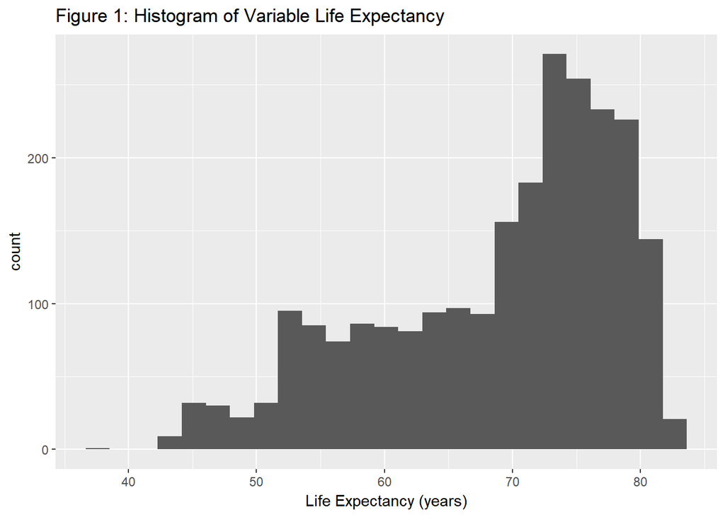

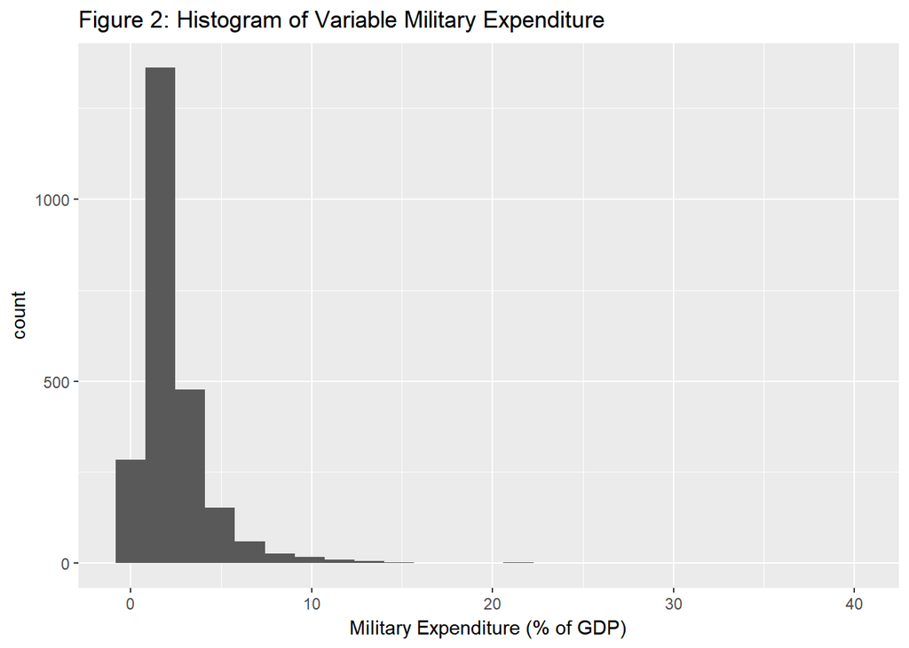

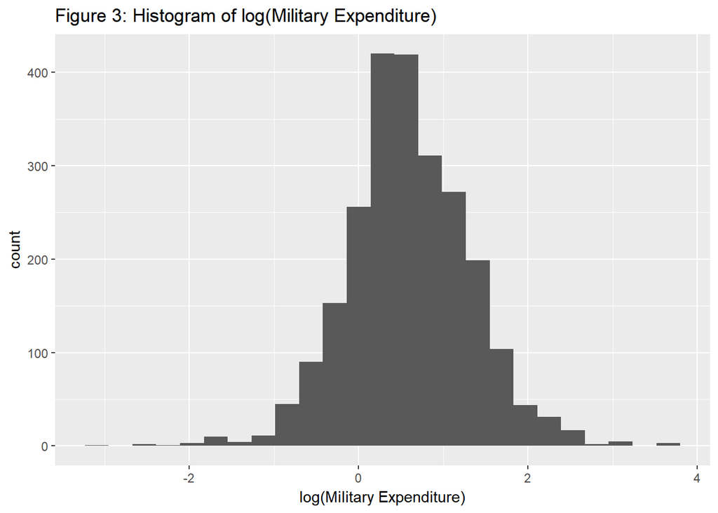

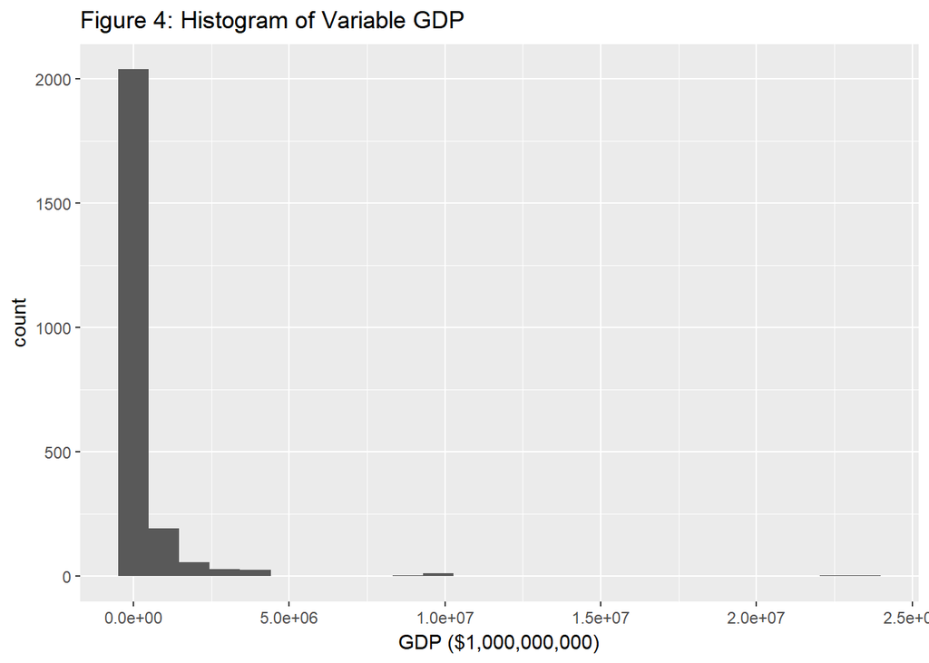

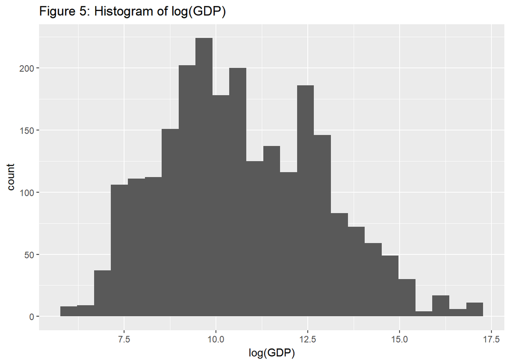

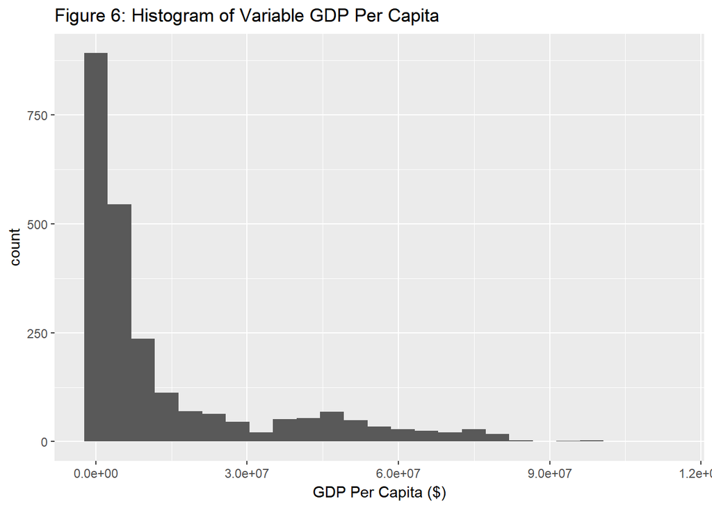

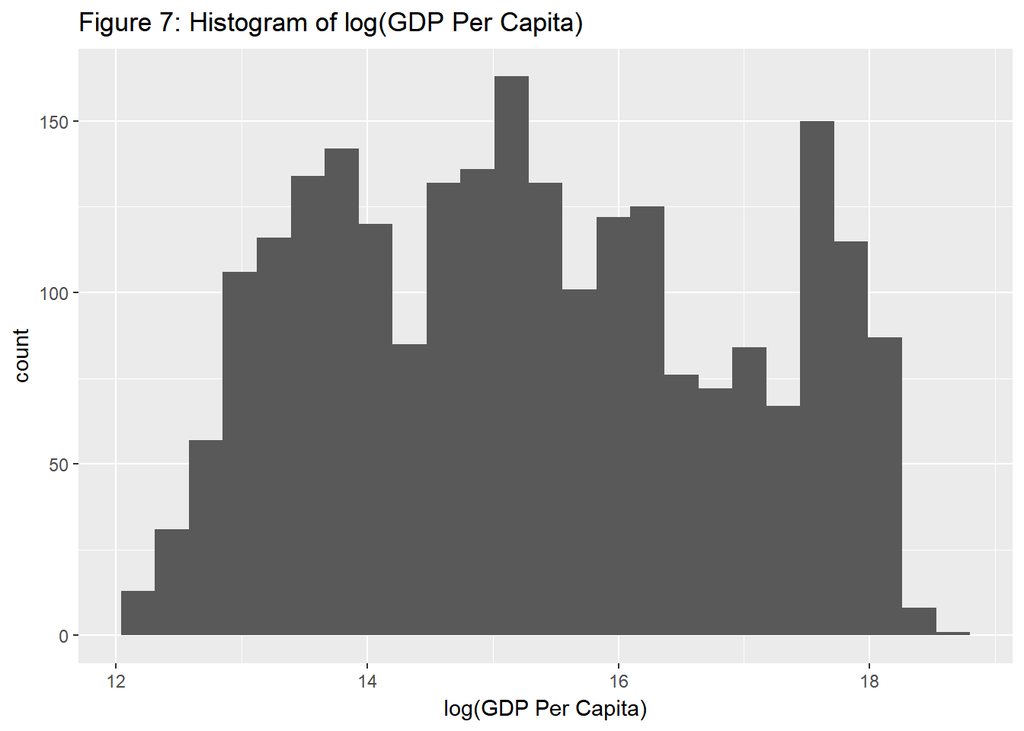

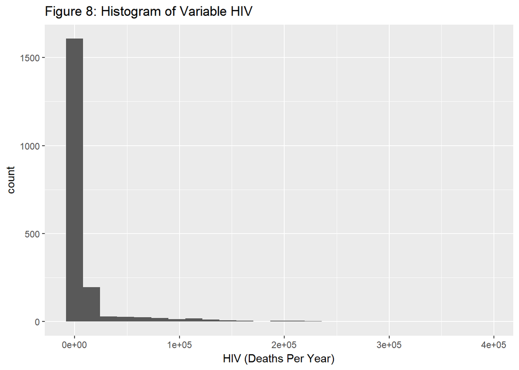

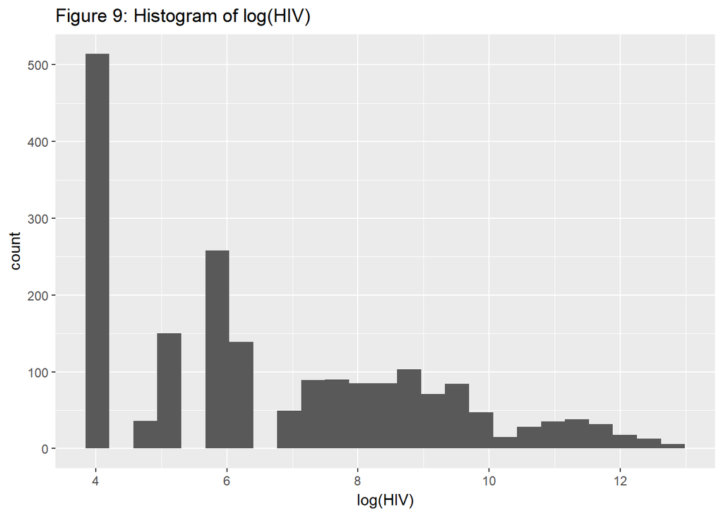

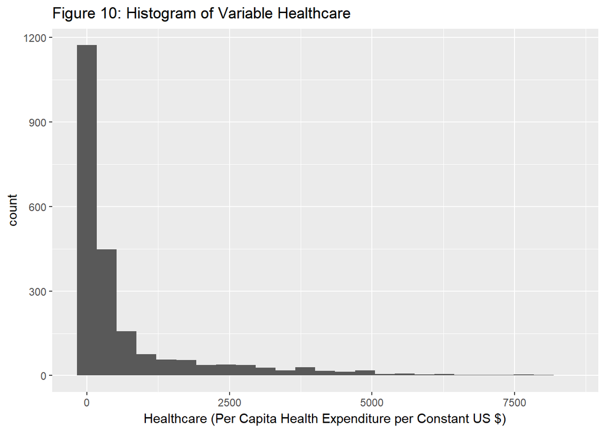

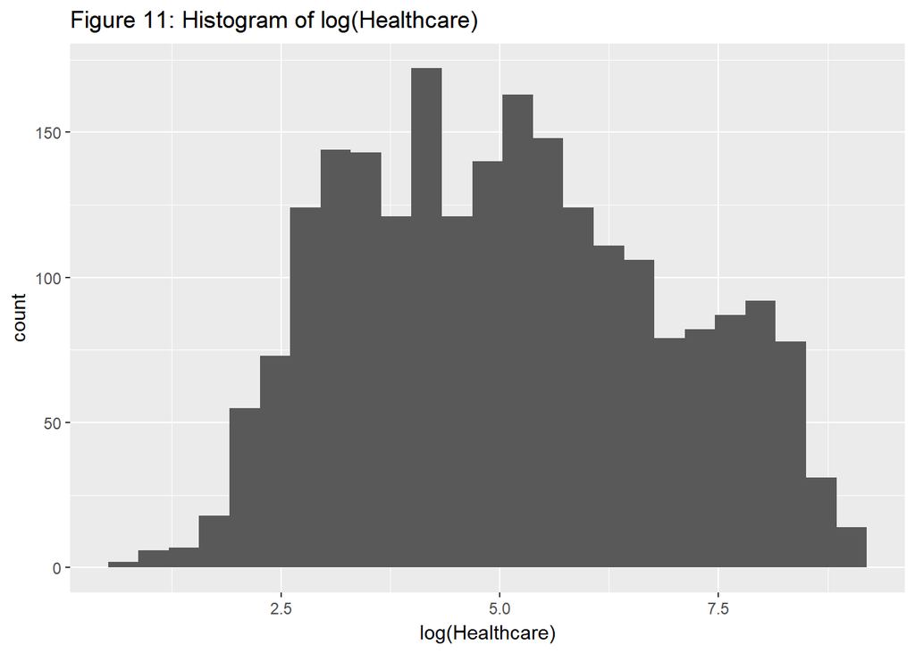

[figure not shown]

[1 more figures not shown]

Figures 14 through 20 show plots of every variable against life expectancy. All of the variables other than HIV and Military Expenditures appeared to have definite associations with Life Expectancy, as the plot for log(HIV) appeared problematic, we decided to test whether or not there was any association between a country’s military expenditures and their mean life expectancy.

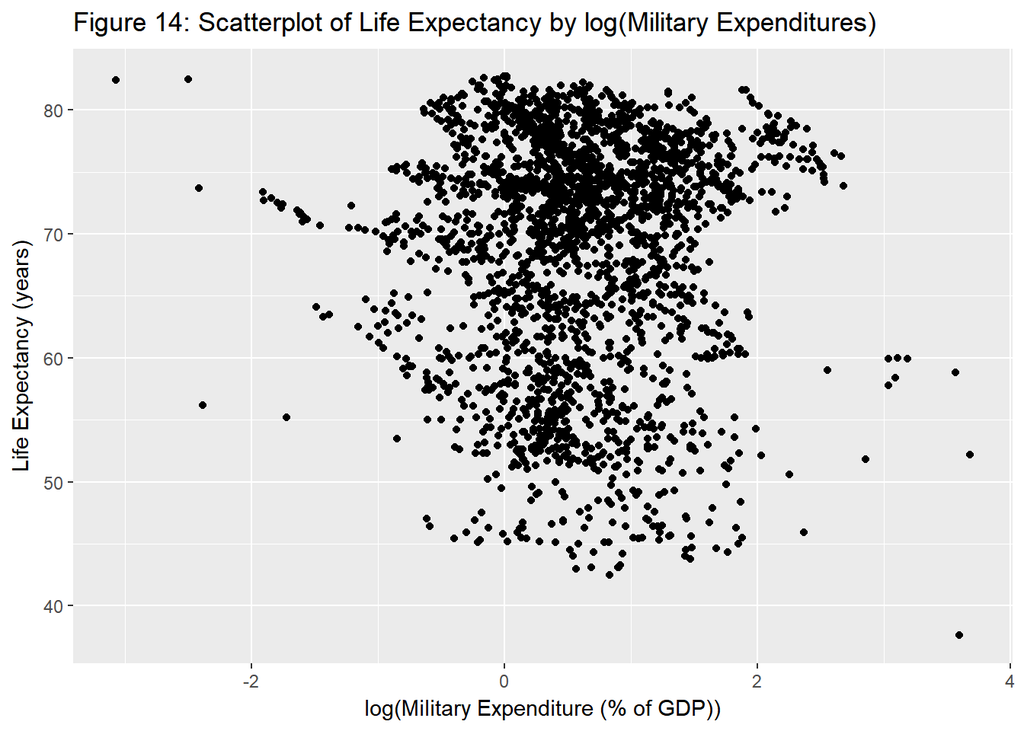

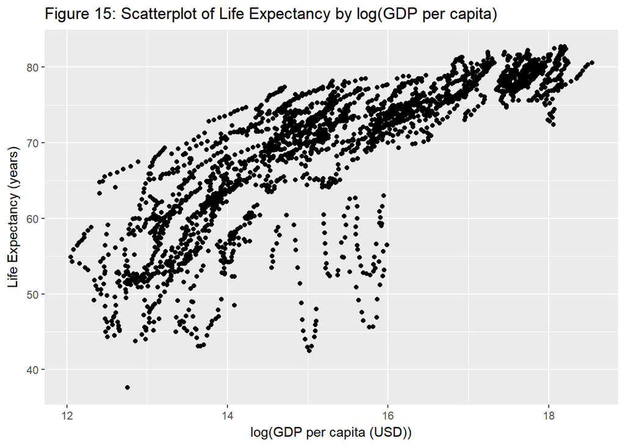

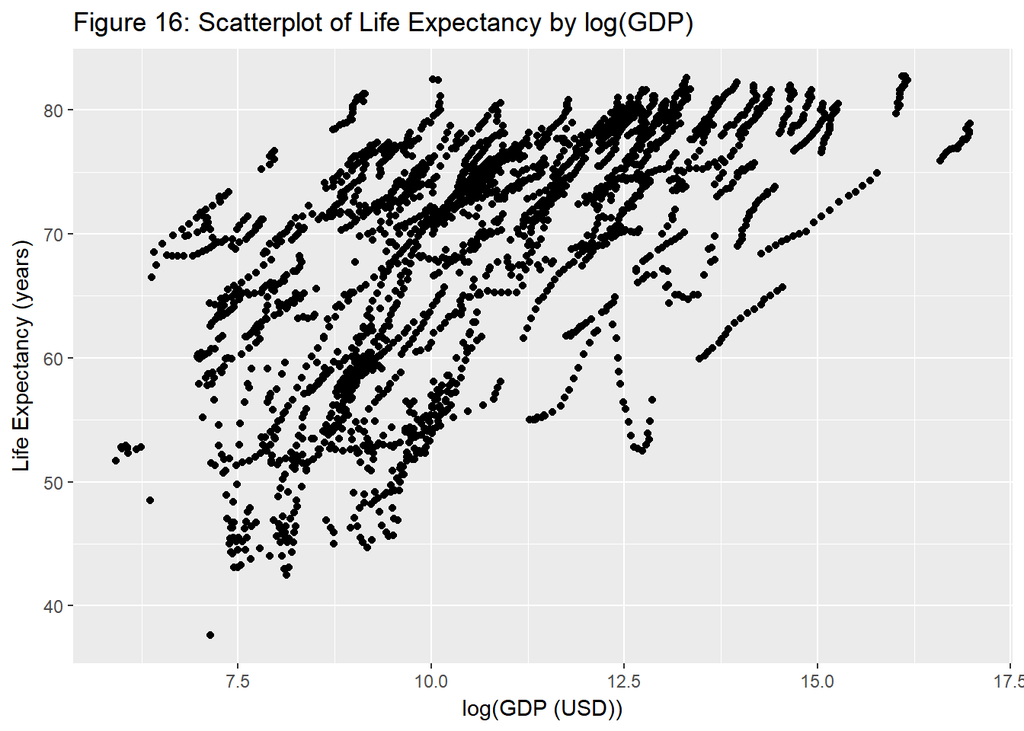

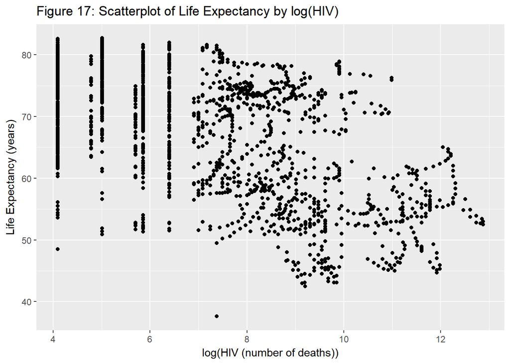

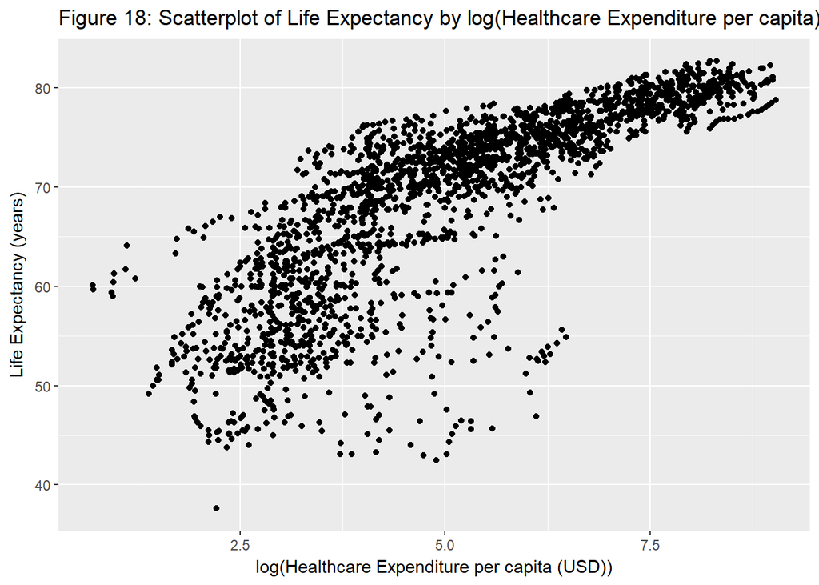

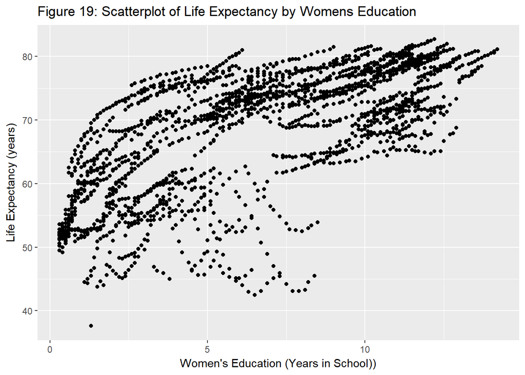

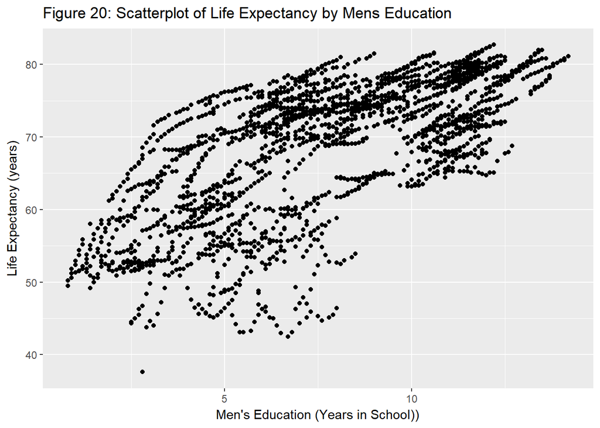

## Econometric Model and Basic Results

To begin constructing our model we created a model excluding the variables GDPpercapita, HIV, and womensEd due to problems with multicollinearity and normality (for explanation see Appendix part: “Model selection”) and conducted a Hausman test in order to see whether it was necessary for us to model our data using a fixed effects model accounting for country as a factor or whether a pooled model would be sufficient. The results are shown in Tables 2 and 3.

```
Table 2: Regression summary for Pooled, Fixed Effects, and Random Effects models
=======================================================================================================
                                                       Dependent variable:
                          -----------------------------------------------------------------------------
                                                             lifeExp
                                   Pooled                 Fixed Effects            Random Effects
                                     (1)                       (2)                       (3)
-------------------------------------------------------------------------------------------------------
log(militaryexpenditures)           0.215                   -0.692***                 -0.641***
                                   (0.177)                   (0.142)                   (0.140)

log(GDP)                          0.663***                  3.850***                  1.961***
                                   (0.077)                   (0.390)                   (0.214)

log(healthcare)                   2.691***                  0.602***                  0.996***
                                   (0.117)                   (0.146)                   (0.129)

menEd                             0.706***                    0.129                   0.639***
                                   (0.058)                   (0.142)                   (0.108)

Constant                          42.289***                                           37.990***
                                   (0.639)                                             (1.794)

-------------------------------------------------------------------------------------------------------
Observations                        1,949                     1,949                     1,949
R2                                  0.657                     0.354                     0.435
Adjusted R2                         0.656                     0.300                     0.434
F Statistic               931.259*** (df = 4; 1944) 246.460*** (df = 4; 1798) 374.557*** (df = 4; 1944)
=======================================================================================================
Note:                                                                       *p<0.1; **p<0.05; ***p<0.01

Table 3: Output of Hausman Test
=========================================
Statistic N  Mean  St. Dev.  Min    Max
-----------------------------------------
statistic 1 82.476          82.476 82.476
p.value   1 0.000             0      0
parameter 1 4.000             4      4
-----------------------------------------
```

We found that with a p-value of $5.2*10^{-17}$ we can safely conclude that a pooled model would be insufficient. Therefore, we arrived at the fixed effects model: $lifeExp = \beta_0 + \beta_1factor(country) + \beta_2log(militaryExp)+\beta_3log(GDP)+\beta_4log(healthcare)+menEd$).

```
Table 4: VIF values for Model without factor(country)
========================================================
log(militaryexpenditures) log(GDP) log(healthcare) menEd
--------------------------------------------------------
1.017                      1.779        2.827      2.143
--------------------------------------------------------

Table 5: VIF statistics for Fixed Effects Model
====================================================
                              GVIF      Df  GVIFDf))
----------------------------------------------------
log(militaryexpenditures)     8.890      1   2.982
log(GDP)                     626.954     1   25.039
log(healthcare)              59.847      1   7.736
menEd                        174.374     1   13.205
factor(country)           2,869,344.000 146  1.052
----------------------------------------------------
```

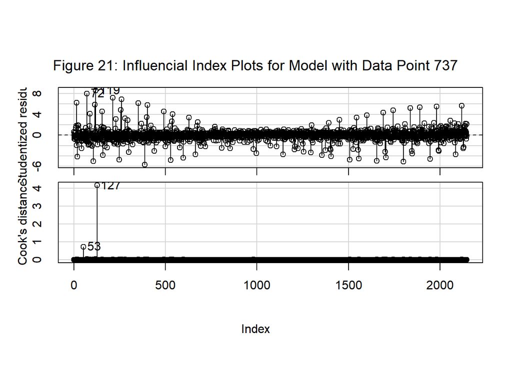

```
Table 6: Model Coefficients for Final Fixed Effects Model (In Both GLM and PLM Form)
==============================================================
                                  Dependent variable:
                          ------------------------------------
                                        lifeExp
                            normal             panel
                                              linear
                             (1)                (2)
--------------------------------------------------------------
log(militaryexpenditures) -0.623***          -0.623***
                           (0.136)            (0.136)

log(GDP)                   3.665***          3.665***
                           (0.373)            (0.373)

log(healthcare)            0.636***          0.636***
                           (0.140)            (0.140)

menEd                       0.183              0.183
                           (0.136)            (0.136)

Constant                  37.959***
                           (2.375)

--------------------------------------------------------------
Observations                1,948              1,948
R2                                             0.372
Adjusted R2                                    0.320
Log Likelihood            -3,392.908
Akaike Inf. Crit.         7,087.815
F Statistic                          266.678*** (df = 4; 1797)
==============================================================
Note:                              *p<0.1; **p<0.05; ***p<0.01
     0.5 %     99.5 %
-0.9731989 -0.2734635
```

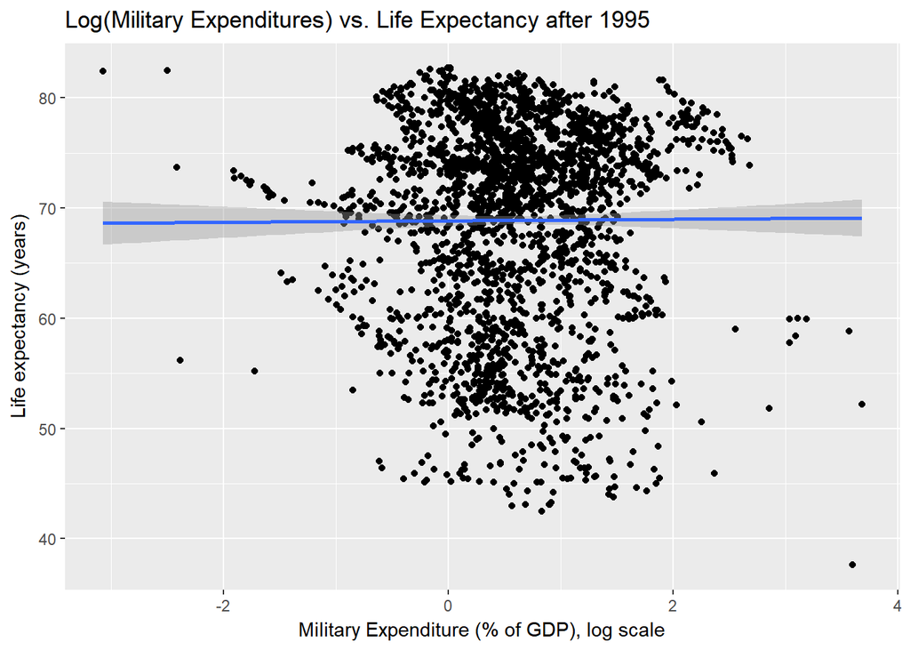

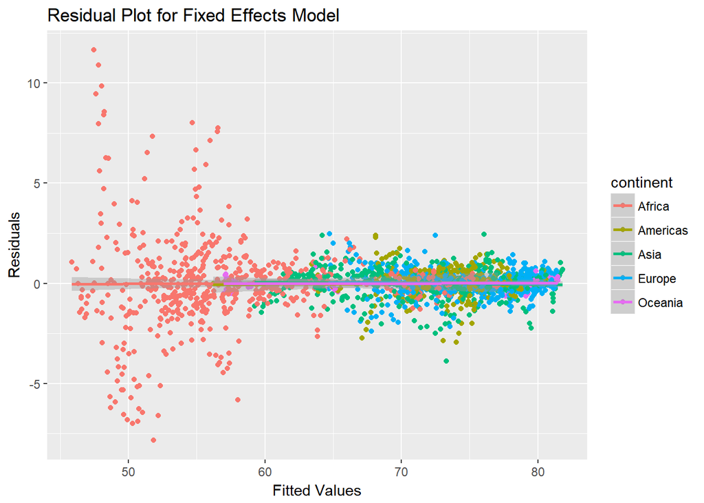

Our Residuals plot of the new model showed strong evidence of heteroskedasticity.

## Robustness

Given the apparent heteroskedasticity in our fixed model we conducted a Breusch-Pagan tests for heteroskedasticity which gave us a p-value of $2.2*10^{-16}$ indicating significant heteroskedasticity in our model

```
    studentized Breusch-Pagan test

data:  projFN.lm
BP = 1076.4, df = 150, p-value < 2.2e-16
```

Given the apparent heteroskedasticity in our model we compared our fixed effects model’s standard errors to the robust standard errors and OLS standard errors in order to see whether or not we needed to adjust our standard errors to account for heteroskedasticity. We found that we did not need to adjust our standard errors because they were fairly similar to one another and did not influence the significance of the model.

```
============================================================
                                 Dependent variable:
                          ----------------------------------
                           lifeExp
                             OLS     hccm default hccm White
                             (1)         (2)         (3)
------------------------------------------------------------
log(militaryexpenditures) -0.623***     -0.623    -0.623***
                           (0.136)                 (0.162)

log(GDP)                   3.665***     3.665      3.665***
                           (0.373)                 (0.486)

log(healthcare)            0.636***     0.636      0.636***
                           (0.140)                 (0.143)

menEd                       0.183       0.183       0.183
                           (0.136)                 (0.199)

Constant                  37.959***     37.959    37.959***
                           (2.375)                 (2.961)

------------------------------------------------------------
Observations                1,948
Log Likelihood            -3,392.908
Akaike Inf. Crit.         7,087.815
============================================================
Note:                            *p<0.1; **p<0.05; ***p<0.01
```

In order to test whether our model showed signs of auto correlation we conducted a Durbin-Watson test on our model, which gave us a p-value of 0.97, meaning we can not reject the null hypothesis of the model having an autocorrelation value equal to 0.

```
    Durbin-Watson test

data:  projFN.lm
DW = 2.0893, p-value = 0.9715
alternative hypothesis: true autocorrelation is greater than 0
```

## Limitations & Future Work

Our model is far from perfect. These variables that we use cannot fully explain the changes we see in life expectancy across countries. We fail to account for the different types of military expenditure, such as technology or wages, as different countries could be allocating their expenditure differently. We also fail to account for countries that are at war. A country that goes to war will increase their military spending and we would expect a country at war to have a lower life expectancy than their norm. This is likely pushing our coefficient on military spending to be more negative. Additionally, as we use military expenditure as a percentage of GDP, a country with a small GDP at war or with its neighbors at war will have a significantly inflated military expenditure. There may also be more advanced models that we failed to consider when analyzing our data. We also fail to take into account inter-country relationships that may skew the data.

If we were to conduct further research on this subject, there are a variety of ideas and variables that it would valuable to consider. Adding utility to the model could help us understand whether military expenditures affected the countries in ways other than life expectancy. It would also be interesting to consider how the model changes when a country is at peace versus actively at war, and how the mortality rate for men aged 18 to 30 changes with both war and increased military expenditure. Considering intra-country violence and crime could allow us to consider how much of a country’s military efforts are focused within its own borders. A comparison of per soldier and per capita or per civilian expenditure might also enable us to determine how much of expenditures pay wages. This could also allow an interesting comparison of wage expenditure versus technological expenditure. Including a dummy variable for first and third world countries could also create an interesting relationship between the amount that a country spend on military and their level of development. These variables would allow us to create a more precise model of what parts of military expenditure affect life expectancy and how countries could use this data to further growth.

## Appendix

```
Table 1: Additional Effect of factor(country) on Constant
=================================================================
                                          Dependent variable:
                                      ---------------------------
                                                lifeExp
-----------------------------------------------------------------
factor(country)Algeria                         -9.846***
                                                (1.667)

factor(country)Angola                         -23.179***
                                                (1.152)

factor(country)Argentina                      -17.845***
                                                (1.606)

factor(country)Armenia                         -1.729***
                                                (0.626)

factor(country)Australia                      -14.515***
                                                (1.463)

factor(country)Austria                        -13.642***
                                                (1.183)

factor(country)Azerbaijan                     -10.026***
                                                (0.604)

factor(country)Bahrain                         -3.369***
                                                (0.703)

factor(country)Belarus                        -12.053***
                                                (0.634)

factor(country)Belgium                        -14.441***
                                                (1.244)

factor(country)Belize                           -0.170
                                                (0.743)

factor(country)Benin                          -13.814***
```

[output cut: 398 more lines]

```
factor(country)Zambia                         -26.187***
                                                (0.677)

factor(country)Zimbabwe                       -25.497***
                                                (0.897)

Constant                                       37.959***
                                                (2.375)

-----------------------------------------------------------------
Observations                                     1,948
Log Likelihood                                -3,392.908
Akaike Inf. Crit.                              7,087.815
=================================================================
Note:                                 *p<0.1; **p<0.05; ***p<0.01
```

#### Model Selection:

First we examined an unrestricted model with all the explanatory variables included

```
Table 3: Model Coefficients for Unrestricted Model
=====================================================
                              Dependent variable:
                          ---------------------------
                                    lifeExp
-----------------------------------------------------
log(militaryexpenditures)          -0.651***
                                    (0.152)

log(GDP)                           1.920***
                                    (0.084)

log(GDPpercap)                     0.797***
                                    (0.285)

log(healthcare)                     0.493**
                                    (0.235)

log(HIV)                           -1.807***
                                    (0.063)

menEd                               0.263*
                                    (0.145)

womenEd                             -0.009
                                    (0.125)

Constant                           43.477***
                                    (3.275)

-----------------------------------------------------
Observations                         1,664
R2                                   0.811
Adjusted R2                          0.811
Residual Std. Error            4.250 (df = 1656)
F Statistic               1,017.379*** (df = 7; 1656)
=====================================================
Note:                     *p<0.1; **p<0.05; ***p<0.01

Table 4: VIF values for Unrestricted Model
=========================================================================================
log(militaryexpenditures) log(GDP) log(GDPpercap) log(healthcare) log(HIV) menEd  womenEd
-----------------------------------------------------------------------------------------
1.028                      3.153       19.930         17.658       2.013   20.569 21.207
-----------------------------------------------------------------------------------------
```

We decided to exclude HIV death rates from our model in favor of healthcare expenditures due to the skewed nature of the HIV data, whether logged or unlogged. We excluded the GDP Per Capita variable in favor of GDP due GDP Per Capita’s high VIF value (Table 4) and excluded Women’s Education in favor of Men’s education because of high multicollinearity between the two (Table 4) and because Men’s education appeared to be more normally distributed (Figure 12).

```
Call:
lm(formula = lifeExp ~ log(militaryexpenditures) + log(GDP) +
    log(healthcare) + menEd, data = metricsProj)

Residuals:
     Min       1Q   Median       3Q      Max
-23.2573  -2.6006   0.3808   3.7245  13.7283

Coefficients:
                          Estimate Std. Error t value Pr(>|t|)
(Intercept)               42.28867    0.63862  66.219   <2e-16 ***
log(militaryexpenditures)  0.21518    0.17663   1.218    0.223
log(GDP)                   0.66288    0.07670   8.642   <2e-16 ***
log(healthcare)            2.69111    0.11722  22.957   <2e-16 ***
menEd                      0.70619    0.05828  12.117   <2e-16 ***
---
Signif. codes:  0 '***' 0.001 '**' 0.01 '*' 0.05 '.' 0.1 ' ' 1

Residual standard error: 5.551 on 1944 degrees of freedom
  (454 observations deleted due to missingness)
Multiple R-squared:  0.6571,    Adjusted R-squared:  0.6564
F-statistic: 931.3 on 4 and 1944 DF,  p-value: < 2.2e-16
```

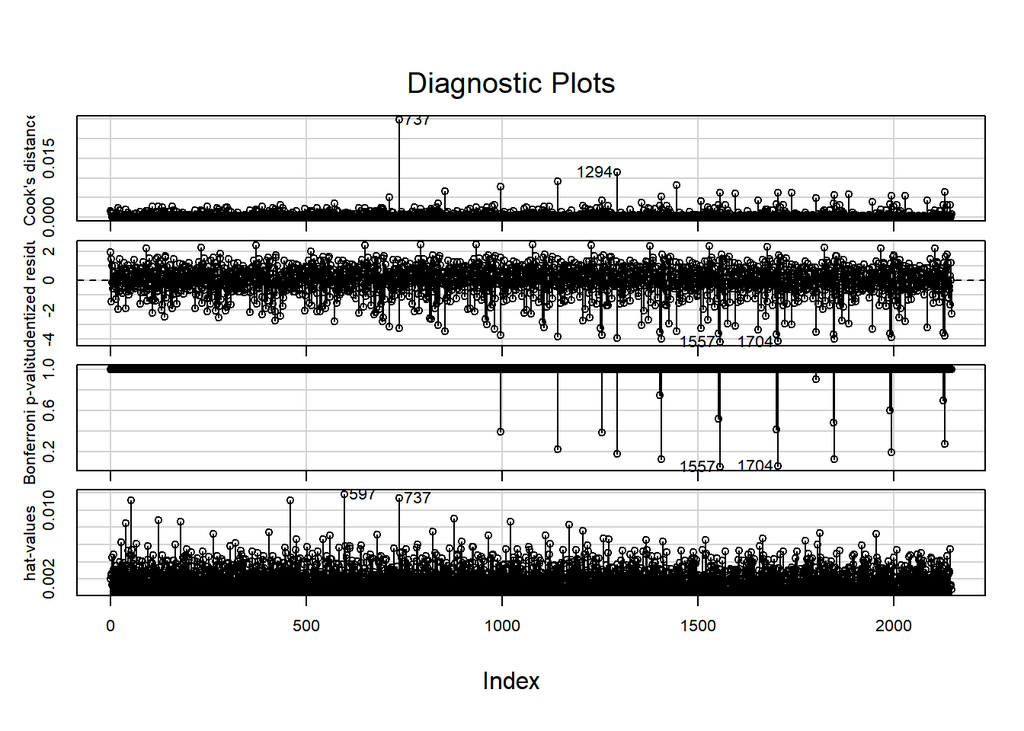

We arrived at the final pooled model( Model 1:$lifeExp = \beta_1 + \beta_2log(militaryExp)+\beta_3log(GDP)+\beta_4log(healthcare)+menEd$ ) Moreover, we chose not to remove any potential outliers from our model as the edited model showed just as many, if not more outliers after being edited, and any continued effort to remove potential outliers could negatively effect our data.

```
Table 5: Model 1
=====================================================
                              Dependent variable:
                          ---------------------------
                                    lifeExp
-----------------------------------------------------
log(militaryexpenditures)            0.215
                                    (0.177)

log(GDP)                           0.663***
                                    (0.077)

log(healthcare)                    2.691***
                                    (0.117)

menEd                              0.706***
                                    (0.058)

Constant                           42.289***
                                    (0.639)

-----------------------------------------------------
Observations                         1,949
R2                                   0.657
Adjusted R2                          0.656
Residual Std. Error            5.551 (df = 1944)
F Statistic                931.259*** (df = 4; 1944)
=====================================================
Note:                     *p<0.1; **p<0.05; ***p<0.01
```

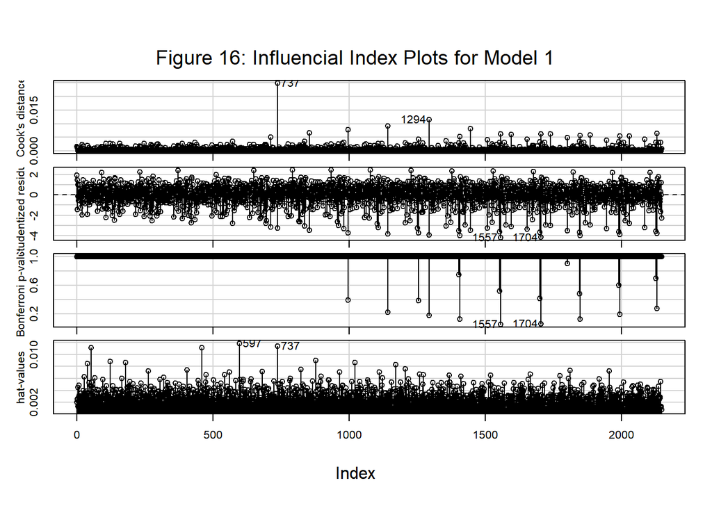

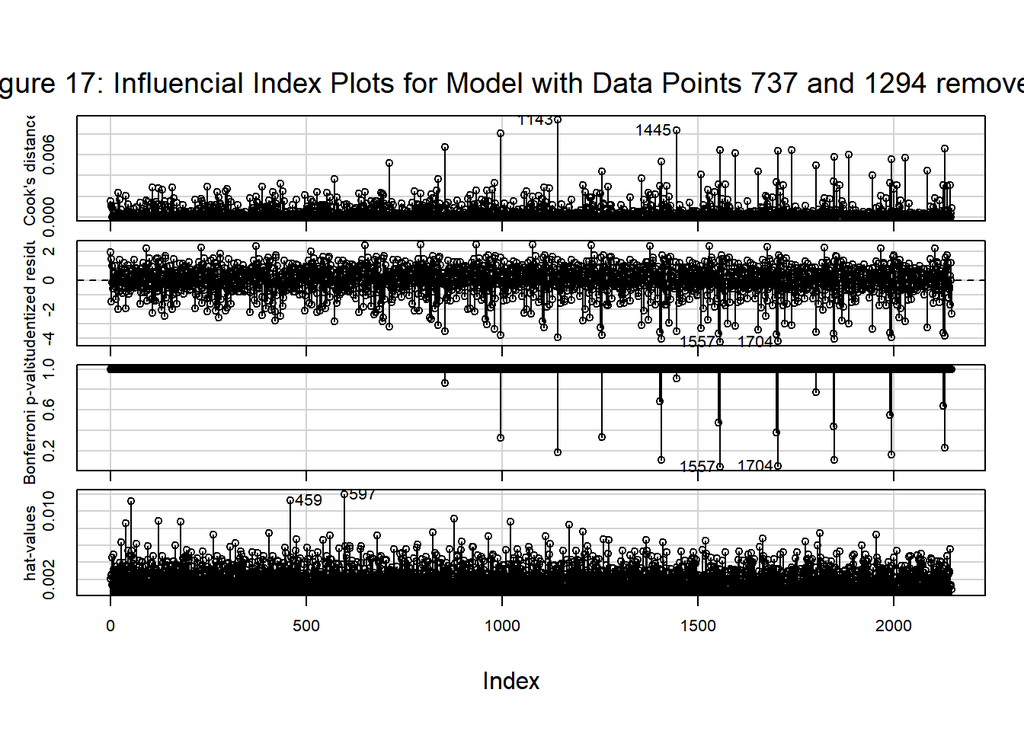

```
Table 6: VIF values for Model 1
========================================================
log(militaryexpenditures) log(GDP) log(healthcare) menEd
--------------------------------------------------------
1.017                      1.779        2.827      2.143
--------------------------------------------------------
```

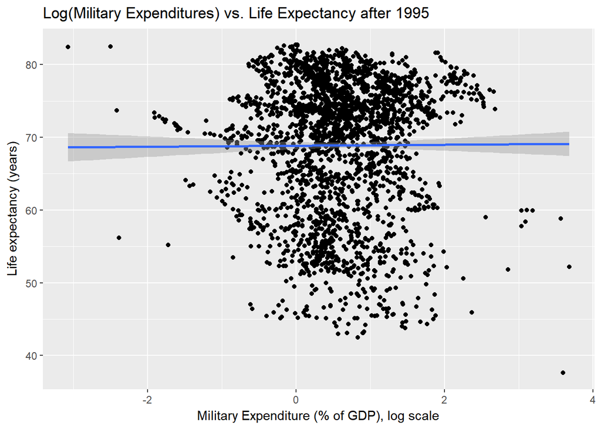

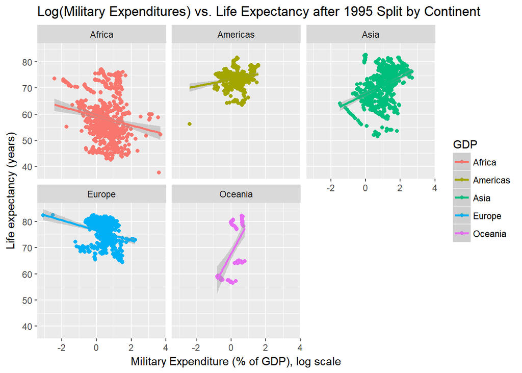

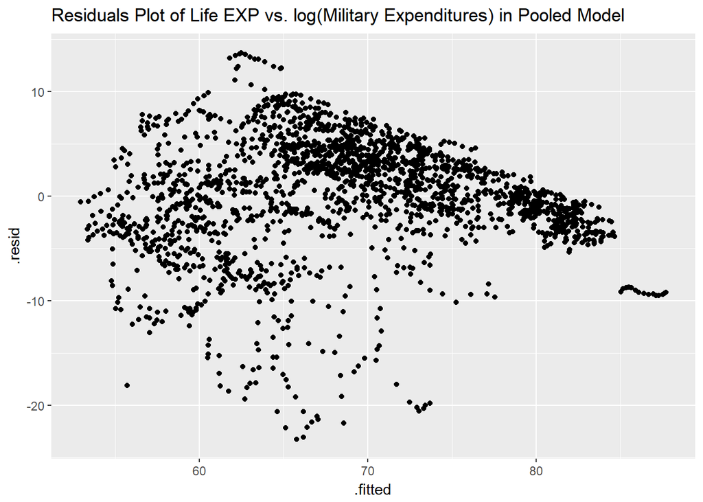

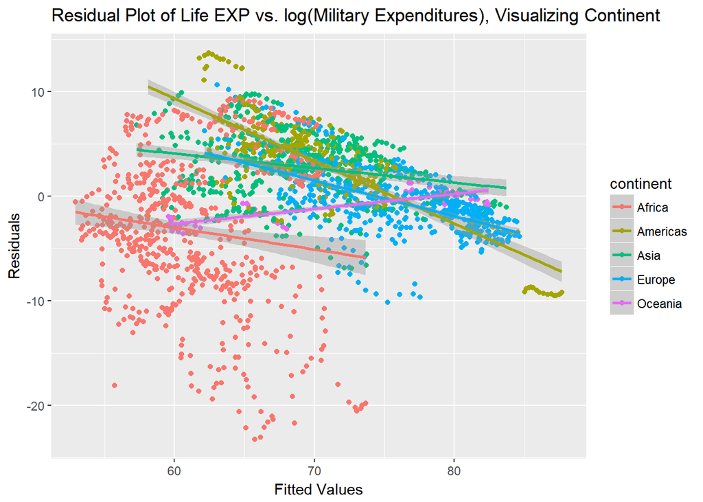

After examining the plots of our pooled model we saw that there was enough variation in the model from continent to continent to justify creating a fixed effects model using country as our influence factor. We chose to use a generalized linear model factoring for country rather than a paneled linear model because, while both models presented us with the same results, the generalized linear model allowed us to more easily present our results graphically.

```
==============================================================
                                  Dependent variable:
                          ------------------------------------
                                        lifeExp
                            normal             panel
                                              linear
                             (1)                (2)
--------------------------------------------------------------
log(militaryexpenditures) -0.623***          -0.623***
                           (0.136)            (0.136)

log(GDP)                   3.665***          3.665***
                           (0.373)            (0.373)

log(healthcare)            0.636***          0.636***
                           (0.140)            (0.140)

menEd                       0.183              0.183
                           (0.136)            (0.136)

Constant                  37.959***
                           (2.375)

--------------------------------------------------------------
Observations                1,948              1,948
R2                                             0.372
Adjusted R2                                    0.320
Log Likelihood            -3,392.908
Akaike Inf. Crit.         7,087.815
F Statistic                          266.678*** (df = 4; 1797)
==============================================================
Note:                              *p<0.1; **p<0.05; ***p<0.01
```

Kentor, Jeffrey, and Andrew Jorgenson. 2017. “Military expenditures and health: a cross-national study, 1975-2000.” *The International Journal of Sociology and Social Policy* 37 (13/14): 755–72. doi:10.1108/IJSSP-01-2017-0004.

Kentor, Jeffrey, and Edward Kick. 2008. “Bringing the Military Back in: Military Expenditures and Economic Growth 1990 to 2003.” *Journal of World-Systems Research* 14 (2): 142–72. doi:10.5195/JWSR.2008.342.

Mahumud, Rashidul Alam, Lal B Rawal, Golam Hossain, Ripter Hossain, and Nurul Islam. 2013. “Impact of Life Expectancy on Economics Growth and Health Care Expenditures: A Case of Bangladesh.” *Universal Journal of Public Health* 1 (4): 180–86. doi:10.13189/ujph.2013.010405.